# M3 Time Series Decomposition Assignment

### Importing Data on Construction Spending

```python
import pandas as pd
import matplotlib.pyplot as plt
%matplotlib inline
import numpy as np
import datetime as dt
from scipy import stats

df = pd.read_csv('C:\\Users\\drh4u\\OneDrive\\Documents\\W&M Fall 2020\\BUAD 5112\\M3\\ConstructionTimeSeriesDatav2.csv')
df = df.rename(columns = {'Month-Year': 'Date','Total Construction': 'Total', 'Private Construction': 'Private', 'Public Construction': 'Public'})
df.head(12)
```

|  | Month | Date | Total | Private | Public |
| --- | --- | --- | --- | --- | --- |
| 0 | 1 | Jan-02 | 59516 | 45273 | 14243 |
| 1 | 2 | Feb-02 | 58588 | 44475 | 14113 |
| 2 | 3 | Mar-02 | 63782 | 49396 | 14386 |
| 3 | 4 | Apr-02 | 69504 | 53283 | 16221 |
| 4 | 5 | May-02 | 73384 | 55009 | 18375 |
| 5 | 6 | Jun-02 | 77182 | 57801 | 19381 |
| 6 | 7 | Jul-02 | 78863 | 58494 | 20369 |
| 7 | 8 | Aug-02 | 79460 | 57953 | 21507 |
| 8 | 9 | Sep-02 | 76542 | 55157 | 21385 |
| 9 | 10 | Oct-02 | 75710 | 56023 | 19687 |
| 10 | 11 | Nov-02 | 71362 | 53552 | 17810 |
| 11 | 12 | Dec-02 | 63984 | 48023 | 15961 |

### Plotting Trends for Total, Private & Public Construction Spending

##### Initial Takeaways

- Both Private and Public construction trends show defined seasonality
- While Public construction shows more linearity, neither Public nor Private construction follow a consistent trend over time
- Private construction is likely showing us a combination of both seasonality and cyclicality BUT we don't see repeated cycles in this data

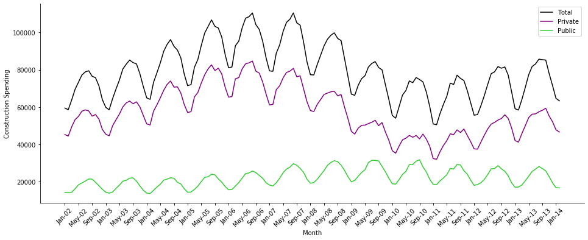

```python
fig, ax = plt.subplots()
fig.set_size_inches(16,6)

plt.plot(df.Date, df.Total, color = 'k', label = 'Total')
plt.plot(df.Date, df.Private, color = 'purple', label = 'Private')
plt.plot(df.Date, df.Public, color = 'limegreen', label = 'Public')

plt.xticks(rotation=45)
ax.set_xticks(df.Date[::4])
ax.set_xticklabels(df.Date[::4])
ax.set_xlabel('Month')
ax.set_ylabel('Construction Spending')
ax.spines['right'].set_visible(False)
ax.spines['top'].set_visible(False)
ax.legend(loc = 1)
plt.show()
```

# Public Construction - Decomposition

- Step 1: plot the Moving Average of our time series where our window is greater than 12 months (if less than our moving average won't smooth out)
- Step 2: determine average Seasonality across monthly increments
- Step 3: combine Moving Average and Seasonality to form a composite model

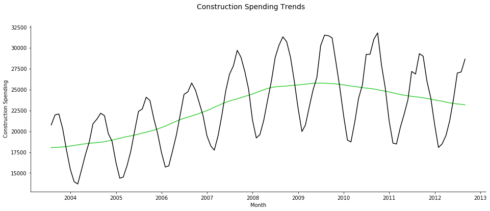

```python
df['MovAvg'] = np.NaN
df['sqErr'] = np.NaN

df.index = pd.DatetimeIndex(freq='m',data=pd.date_range(freq='m',start=pd.Timestamp(year=2002,month=1,day=31),periods=len(df.Public)))

window = 36  # (months)
window = window - window % 2

for i in range(int(window/2),df.shape[0]-int(window/2)):
    df.loc[df.index[i],'MovAvg'] = (0.5*df.iloc[i - int(window/2)]['Public'] + df.iloc[i - int(window/2)+1:i + int(window/2)]['Public'].sum() + 0.5*df.iloc[i + int(window/2)]['Public'])/float(window)

df['sqErr'] = (df['Public'] - df['MovAvg'])**2
df.dropna(how='any',inplace=True)  # drop any rows that we cannot compute a moving average for

fig,ax = plt.subplots()
fig.suptitle('Construction Spending Trends', fontsize = 14)
fig.set_size_inches(16,6)
ax.plot(df['MovAvg'],label='Moving Avg', color = 'limegreen')
ax.plot(df['Public'],label='Actual', color = 'black')
ax.set_xlabel('Month')
ax.set_ylabel('Construction Spending')
ax.spines['right'].set_visible(False)
ax.spines['top'].set_visible(False)
```

### Plotting Residuals Post-Moving Average

##### Takeaways:

- Seasonality pattern looks to explain most of the remaining residuals
- In some cases the Seasonality looks to be more pronounced (later years show more variance and earlier years)

```
Average Residual:  120.58522727272724
```

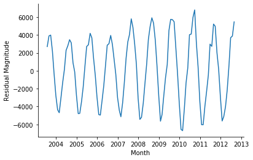

```python
df['R1'] = df['Public'] - df['MovAvg']   # 1st remainder
df['R1Error'] = abs((df['Public'] - df['R1'])/df['Public'])
df.style.format({
    'MovAvg': '{:.1f}'.format,
    'sqErr': '{:,.1f}'.format,
    'R1': '{:,.1f}'.format,
    'R1Error': '{:,.3f}'.format
})

fig,ax = plt.subplots()
ax.plot(df['R1'])
ax.set_xlabel('Month')
ax.set_ylabel('Residual Magnitude')
ax.spines['right'].set_visible(False)
ax.spines['top'].set_visible(False)
print('Average Residual: ', sum(df['R1'])/len(df))
```

### Running Autocorrelation to Determine Seasonality Increments

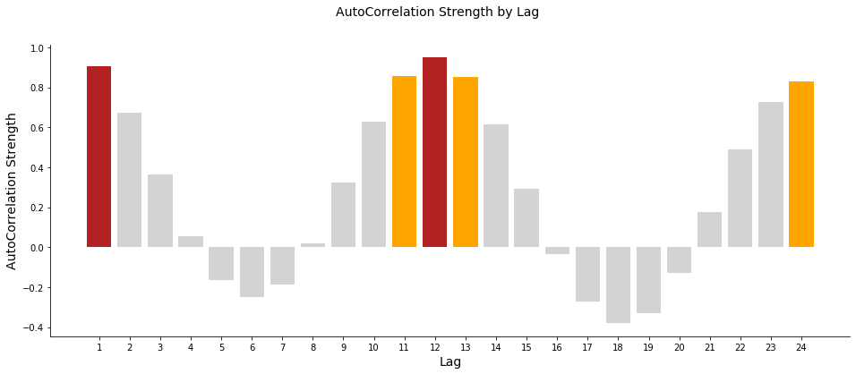

```python
auto_corr = pd.DataFrame(columns = ['Lag_Value', 'AutoCorr'])

for i in range(1,25):   # int(len(df.index)/2)
    auto_corr.loc[i,'Lag_Value'] = i
    auto_corr.loc[i,'AutoCorr'] = df.Public.autocorr(lag = i)

color_cond = ['firebrick' if ac >= 0.9 else ('orange' if ac > 0.75 else 'lightgrey') for ac in auto_corr['AutoCorr']]

fig,ax = plt.subplots()
fig.suptitle('AutoCorrelation Strength by Lag', fontsize = 14)
fig.set_size_inches(16,6)
plt.bar(auto_corr.Lag_Value,auto_corr.AutoCorr, color = color_cond)
ax.set_xticks(auto_corr.Lag_Value[::1])
ax.set_xticklabels(auto_corr.Lag_Value[::1])
ax.set_xlabel('Lag', fontsize = 14)
ax.set_ylabel('AutoCorrelation Strength', fontsize = 14)
ax.spines['right'].set_visible(False)
ax.spines['top'].set_visible(False)
plt.show()
```

### Calculating Average Deviations Based on Month from our Residuals Post-Moving Average

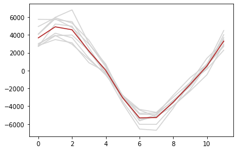

```python
dfMonth = pd.DataFrame()  # empty dataframe
cycleLen = 12
for i in range(int(len(df.index)/cycleLen)):
    newData = pd.DataFrame({i:df['R1'].iloc[i*cycleLen:(i+1)*cycleLen]})
    newData.index = range(0,len(newData))
    dfMonth = pd.concat([dfMonth,newData],axis=1)

avg = []
for i in range(len(dfMonth.index)):
    avg.append(dfMonth.iloc[i].mean())

dfMonth = pd.concat([dfMonth,pd.DataFrame({'avg':avg})], axis=1)


fig,ax = plt.subplots()
for col in dfMonth.columns.values:  # this is crafty AF
    if col == 'avg':
        ax.plot(dfMonth[col], c = 'firebrick')
    else:
        ax.plot(dfMonth[col], c = 'lightgrey')
display()
```

### Adding in Seasonality to our Model from the Residual-Based Averages

```python
df.reset_index(inplace = True)

df['S'] = np.NaN    # seasonal effect in each quarter, we will subtract this from R1
df['R2'] = np.NaN    # will serve as remainder after accounting for seasonality (the noise)
df['Composite'] = np.NaN   # total model (level + Trend + Seasonal)
df['errorPerc'] = np.NaN   # % of error from our noise
S = dfMonth['avg'].tolist()
for i in df.index:
    df.loc[i,'S'] = S[i%cycleLen]
    df.loc[i,'R2'] = df.loc[i,'R1'] - df.loc[i,'S']
    df.loc[i,'Composite'] = df.loc[i,'MovAvg'] + df.loc[i,'S']
    df.loc[i,'errorPerc'] = 100*df.loc[i,'R2'] / df.loc[i,'Public']
df.style.format({
    'Public': '{:,.0f}'.format,
    'MovAvg': '{:,.0f}'.format,
    'sqErr': '{:,.0f}'.format,
    'R1': '{:,.0f}'.format,
    'S': '{:,.0f}'.format,
    'R2': '{:,.0f}'.format,
    'Composite':'{:,.0f}'.format,
    'errorPerc': '{:.2f}%'.format    # two decimal places with %
})
```

|  | index | Month | Date | Total | Private | Public | MovAvg | sqErr | R1 | R1Error | S | R2 | Composite | errorPerc |
| --- | --- | --- | --- | --- | --- | --- | --- | --- | --- | --- | --- | --- | --- | --- |
| 0 | 2003-07-31 00:00:00 | 19 | Jul-03 | 82971 | 62216 | 20,755 | 18,050 | 7,314,395 | 2,705 | 0.869693 | 3,670 | -965 | 21,720 | -4.65% |
| 1 | 2003-08-31 00:00:00 | 20 | Aug-03 | 85191 | 63234 | 21,957 | 18,058 | 15,202,201 | 3,899 | 0.822426 | 4,906 | -1,007 | 22,964 | -4.58% |
| 2 | 2003-09-30 00:00:00 | 21 | Sep-03 | 83841 | 61767 | 22,075 | 18,085 | 15,920,765 | 3,990 | 0.819249 | 4,573 | -583 | 22,658 | -2.64% |
| 3 | 2003-10-31 00:00:00 | 22 | Oct-03 | 83133 | 62813 | 20,321 | 18,126 | 4,817,354 | 2,195 | 0.891991 | 2,192 | 3 | 20,318 | 0.01% |
| 4 | 2003-11-30 00:00:00 | 23 | Nov-03 | 77915 | 60115 | 17,801 | 18,170 | 136,161 | -369 | 1.020729 | 16 | -385 | 18,186 | -2.16% |
| 5 | 2003-12-31 00:00:00 | 24 | Dec-03 | 71050 | 55584 | 15,466 | 18,236 | 7,670,130 | -2,770 | 1.179070 | -3,046 | 277 | 15,189 | 1.79% |
| 6 | 2004-01-31 00:00:00 | 25 | Jan-04 | 64934 | 50975 | 13,959 | 18,309 | 18,923,950 | -4,350 | 1.311639 | -5,302 | 952 | 13,007 | 6.82% |
| 7 | 2004-02-29 00:00:00 | 26 | Feb-04 | 64138 | 50449 | 13,689 | 18,377 | 21,976,953 | -4,688 | 1.342462 | -5,274 | 586 | 13,103 | 4.28% |
| 8 | 2004-03-31 00:00:00 | 27 | Mar-04 | 73238 | 57796 | 15,443 | 18,445 | 9,009,669 | -3,002 | 1.194367 | -3,546 | 544 | 14,899 | 3.52% |
| 9 | 2004-04-30 00:00:00 | 28 | Apr-04 | 78354 | 61177 | 17,177 | 18,502 | 1,755,625 | -1,325 | 1.077138 | -1,572 | 247 | 16,930 | 1.44% |
| 10 | 2004-05-31 00:00:00 | 29 | May-04 | 83736 | 65027 | 18,709 | 18,555 | 23,797 | 154 | 0.991755 | 511 | -357 | 19,066 | -1.91% |
| 11 | 2004-06-30 00:00:00 | 30 | Jun-04 | 89932 | 69039 | 20,893 | 18,603 | 5,243,591 | 2,290 | 0.890399 | 3,308 | -1,019 | 21,912 | -4.88% |
| 12 | 2004-07-31 00:00:00 | 31 | Jul-04 | 93614 | 72170 | 21,444 | 18,642 | 7,848,636 | 2,802 | 0.869355 | 3,670 | -868 | 22,312 | -4.05% |
| 13 | 2004-08-31 00:00:00 | 32 | Aug-04 | 96164 | 74001 | 22,164 | 18,688 | 12,083,831 | 3,476 | 0.843161 | 4,906 | -1,430 | 23,594 | -6.45% |
| 14 | 2004-09-30 00:00:00 | 33 | Sep-04 | 92538 | 70662 | 21,876 | 18,759 | 9,714,996 | 3,117 | 0.857520 | 4,573 | -1,456 | 23,332 | -6.66% |
| 15 | 2004-10-31 00:00:00 | 34 | Oct-04 | 90582 | 70856 | 19,726 | 18,846 | 773,765 | 880 | 0.955407 | 2,192 | -1,312 | 21,038 | -6.65% |
| 16 | 2004-11-30 00:00:00 | 35 | Nov-04 | 86394 | 67585 | 18,809 | 18,942 | 17,815 | -133 | 1.007096 | 16 | -150 | 18,959 | -0.80% |
| 17 | 2004-12-31 00:00:00 | 36 | Dec-04 | 77733 | 61438 | 16,295 | 19,053 | 7,604,419 | -2,758 | 1.169231 | -3,046 | 289 | 16,006 | 1.77% |
| 18 | 2005-01-31 00:00:00 | 37 | Jan-05 | 71474 | 57094 | 14,380 | 19,165 | 22,894,364 | -4,785 | 1.332740 | -5,302 | 517 | 13,863 | 3.60% |
| 19 | 2005-02-28 00:00:00 | 38 | Feb-05 | 72048 | 57531 | 14,517 | 19,273 | 22,620,329 | -4,756 | 1.327622 | -5,274 | 518 | 13,999 | 3.57% |
| 20 | 2005-03-31 00:00:00 | 39 | Mar-05 | 81345 | 65425 | 15,920 | 19,366 | 11,873,576 | -3,446 | 1.216445 | -3,546 | 100 | 15,820 | 0.63% |
| 21 | 2005-04-30 00:00:00 | 40 | Apr-05 | 85485 | 67829 | 17,656 | 19,448 | 3,210,916 | -1,792 | 1.101490 | -1,572 | -219 | 17,875 | -1.24% |
| 22 | 2005-05-31 00:00:00 | 41 | May-05 | 92959 | 72862 | 20,097 | 19,547 | 302,424 | 550 | 0.972636 | 511 | 39 | 20,058 | 0.19% |
| 23 | 2005-06-30 00:00:00 | 42 | Jun-05 | 99632 | 77258 | 22,375 | 19,659 | 7,375,449 | 2,716 | 0.878624 | 3,308 | -593 | 22,968 | -2.65% |
| 24 | 2005-07-31 00:00:00 | 43 | Jul-05 | 103158 | 80480 | 22,679 | 19,774 | 8,437,411 | 2,905 | 0.871920 | 3,670 | -765 | 23,444 | -3.37% |
| 25 | 2005-08-31 00:00:00 | 44 | Aug-05 | 106706 | 82629 | 24,078 | 19,890 | 17,538,762 | 4,188 | 0.826068 | 4,906 | -718 | 24,796 | -2.98% |
| 26 | 2005-09-30 00:00:00 | 45 | Sep-05 | 103269 | 79584 | 23,685 | 20,003 | 13,559,170 | 3,682 | 0.844531 | 4,573 | -891 | 24,576 | -3.76% |
| 27 | 2005-10-31 00:00:00 | 46 | Oct-05 | 102339 | 80820 | 21,519 | 20,125 | 1,942,423 | 1,394 | 0.935234 | 2,192 | -798 | 22,317 | -3.71% |
| 28 | 2005-11-30 00:00:00 | 47 | Nov-05 | 97549 | 77774 | 19,775 | 20,277 | 251,753 | -502 | 1.025373 | 16 | -518 | 20,293 | -2.62% |
| 29 | 2005-12-31 00:00:00 | 48 | Dec-05 | 88172 | 70692 | 17,479 | 20,445 | 8,794,685 | -2,966 | 1.169666 | -3,046 | 81 | 17,398 | 0.46% |

[output cut: 80 more lines]

### Plotting The Revised Model With Both Trend (Moving Average) and Seasonality Accounted For

Overall, this model fits well with the actual trend for Public construction. The remaining error in the model is driven by differences in variance of the seasonal fluctuations over time within the trend. Because we used the average seasonality in our adjusted model, we overshoot the seasonality in earlier years and undershoot it in later years.

[figure not shown]

```python
x = df['Date']

fig, ax = plt.subplots()
fig.suptitle('Fitted Model vs. Actual Data: Private Construction', fontsize = 14)
fig.set_size_inches(16,6)
ax.plot(x, df['Public'],c='black', label = 'Actual')
ax.plot(x, df['Composite'],c='limegreen', label = 'Model', linestyle = 'dashed')   # 'Composite' serves as our model
ax.set_xticks(x[::4])
ax.set_xticklabels(x[::4])
ax.spines['top'].set_visible(False)
ax.spines['right'].set_visible(False)
ax.set_xlabel('Month', fontsize = 14)
plt.xticks(rotation=45)
ax.set_ylabel('Public Construction Spending', fontsize = 14)
ax.legend(loc = 2, fontsize = 14)
plt.show()
```

### Plotting Our Remaining Residuals

Our remaining residuals loosely follow a normal distribution.

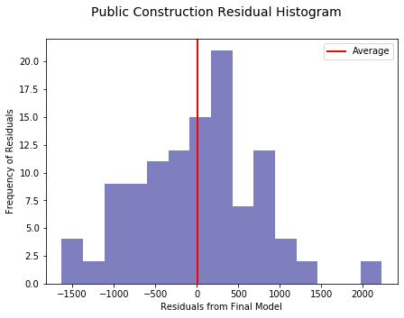

```python
avg_resid = df['R2'].mean()

fig, ax = plt.subplots()
ax.hist(x = df['R2'], bins = 15, facecolor='navy', alpha=0.5)
# 'hist' signals a histogram

fig.suptitle('Public Construction Residual Histogram', fontsize = 14)
fig.set_size_inches(7,5)
ax.axvline(x=avg_resid,linewidth=2,color='red',linestyle='-', label = 'Average')

ax.xaxis.set_label_text('Residuals from Final Model')
ax.xaxis.set_tick_params(which = 'both', top = False, bottom = True, labelbottom = True)  # Turn top x axis tick marks off
ax.yaxis.set_label_text('Frequency of Residuals')
ax.yaxis.set_tick_params(which = 'both', right = False, left = True, labelleft = True)   # Turn right y axis tick marks off
ax.legend()
plt.show()
```

# Decomposition of Private Construction

For the Private Construction trend, I employed the same method. As an alternate route, you could look to combine seasonality and cyclicality; however, our line of sight on cyclicality is limited with the data we have because we cannot easily spot a repeated cycle.

```python
priv_df = pd.read_csv('C:\\Users\\drh4u\\OneDrive\\Documents\\W&M Fall 2020\\BUAD 5112\\M3\\ConstructionTimeSeriesDatav2.csv')
priv_df = priv_df.rename(columns = {'Month-Year': 'Date','Total Construction': 'Total', 'Private Construction': 'Private', 'Public Construction': 'Public'})
priv_df.head(12)
```

|  | Month | Date | Total | Private | Public |
| --- | --- | --- | --- | --- | --- |
| 0 | 1 | Jan-02 | 59516 | 45273 | 14243 |
| 1 | 2 | Feb-02 | 58588 | 44475 | 14113 |
| 2 | 3 | Mar-02 | 63782 | 49396 | 14386 |
| 3 | 4 | Apr-02 | 69504 | 53283 | 16221 |
| 4 | 5 | May-02 | 73384 | 55009 | 18375 |
| 5 | 6 | Jun-02 | 77182 | 57801 | 19381 |
| 6 | 7 | Jul-02 | 78863 | 58494 | 20369 |
| 7 | 8 | Aug-02 | 79460 | 57953 | 21507 |
| 8 | 9 | Sep-02 | 76542 | 55157 | 21385 |
| 9 | 10 | Oct-02 | 75710 | 56023 | 19687 |
| 10 | 11 | Nov-02 | 71362 | 53552 | 17810 |
| 11 | 12 | Dec-02 | 63984 | 48023 | 15961 |

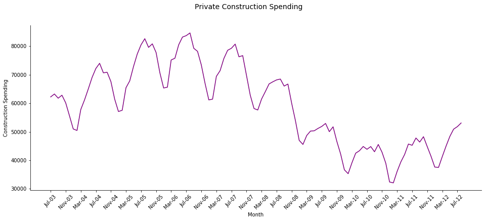

```python
fig, ax = plt.subplots()
fig.set_size_inches(16,6)
fig.suptitle('Private Construction Spending', fontsize = 14)
plt.plot(df.Date, df.Private, color = 'purple', label = 'Private')

plt.xticks(rotation=45)
ax.set_xticks(df.Date[::4])
ax.set_xticklabels(df.Date[::4])
ax.set_xlabel('Month')
ax.set_ylabel('Construction Spending')
ax.spines['right'].set_visible(False)
ax.spines['top'].set_visible(False)
plt.show()
```

### Creating the Moving Average and Plotting it for Private Construction

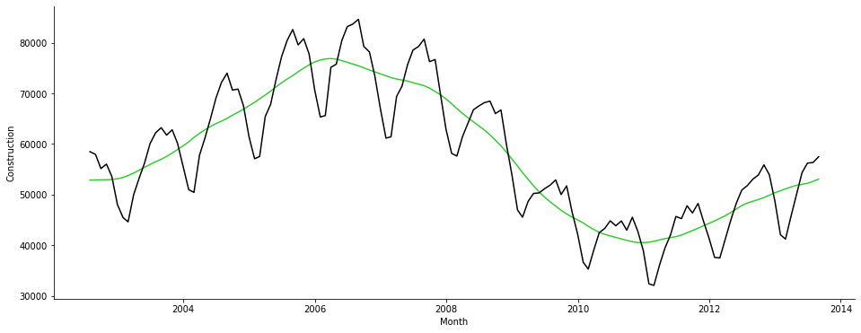

```python
priv_df['MovAvg'] = np.NaN
priv_df['sqErr'] = np.NaN

priv_df.index = pd.DatetimeIndex(freq='m',data=pd.date_range(freq='m',start=pd.Timestamp(year=2002,month=1,day=31),periods=len(priv_df.Private)))

window = 12  # (months)
window = window - window % 2

for i in range(int(window/2),priv_df.shape[0]-int(window/2)):
    priv_df.loc[priv_df.index[i],'MovAvg'] = (0.5*priv_df.iloc[i - int(window/2)]['Private'] + priv_df.iloc[i - int(window/2)+1:i + int(window/2)]['Private'].sum() + 0.5*priv_df.iloc[i + int(window/2)]['Private'])/float(window)

priv_df['sqErr'] = (priv_df['Private'] - priv_df['MovAvg'])**2
priv_df.dropna(how='any',inplace=True)  # drop any rows that we cannot compute a moving average for

fig,ax = plt.subplots()
fig.set_size_inches(16,6)
ax.plot(priv_df['MovAvg'],label='Moving Avg', color = 'limegreen')
ax.plot(priv_df['Private'],label='Actual', color = 'black')
ax.set_xlabel('Month')
ax.set_ylabel('Construction')
ax.spines['right'].set_visible(False)
ax.spines['top'].set_visible(False)
```

### Assessing Seasonality within our Residuals Post-Moving Average

```
Average Residual:  30.595149253731616
```

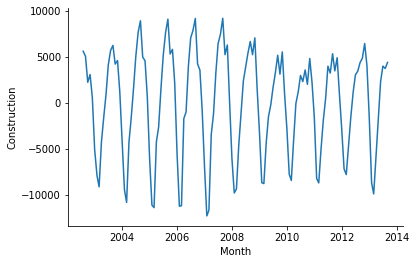

```python
priv_df['R1'] = priv_df['Private'] - priv_df['MovAvg']   # 1st remainder
priv_df['R1Error'] = abs((priv_df['Private'] - priv_df['R1'])/priv_df['Private'])
priv_df.style.format({
    'MovAvg': '{:.1f}'.format,
    'sqErr': '{:,.1f}'.format,
    'R1': '{:,.1f}'.format,
    'R1Error': '{:,.3f}'.format
})

fig,ax = plt.subplots()
ax.plot(priv_df['R1'])
ax.set_xlabel('Month')
ax.set_ylabel('Construction')
ax.spines['right'].set_visible(False)
ax.spines['top'].set_visible(False)
print('Average Residual: ', sum(priv_df['R1'])/len(priv_df))
```

### Using AutoCorrelation to Define the Seasonality

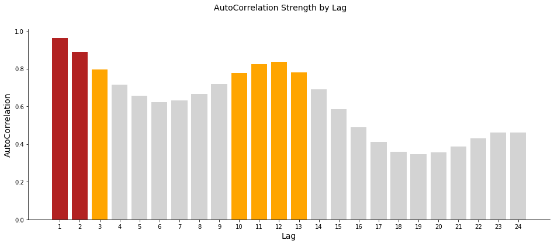

```python
priv_auto_corr = pd.DataFrame(columns = ['Lag_Value', 'AutoCorr'])

for i in range(1,25):   # int(len(df.index)/2)
    priv_auto_corr.loc[i,'Lag_Value'] = i
    priv_auto_corr.loc[i,'AutoCorr'] = priv_df.Private.autocorr(lag = i)

color_cond = ['firebrick' if ac >= 0.85 else ('orange' if ac > 0.75 else 'lightgrey') for ac in priv_auto_corr['AutoCorr']]

fig,ax = plt.subplots()
fig.suptitle('AutoCorrelation Strength by Lag', fontsize = 14)
fig.set_size_inches(16,6)
plt.bar(priv_auto_corr.Lag_Value, priv_auto_corr.AutoCorr, color = color_cond)
ax.set_xticks(priv_auto_corr.Lag_Value[::1])
ax.set_xticklabels(priv_auto_corr.Lag_Value[::1])
ax.set_xlabel('Lag', fontsize = 14)
ax.set_ylabel('AutoCorrelation', fontsize = 14)
ax.spines['right'].set_visible(False)
ax.spines['top'].set_visible(False)
plt.show()
```

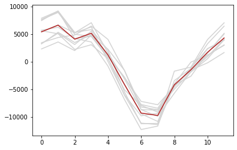

```python
priv_dfMonth = pd.DataFrame()  # empty dataframe
cycleLen = 12
for i in range(int(len(priv_df.index)/cycleLen)):
    newData = pd.DataFrame({i:priv_df['R1'].iloc[i*cycleLen:(i+1)*cycleLen]})
    newData.index = range(0,len(newData))
    priv_dfMonth = pd.concat([priv_dfMonth,newData],axis=1)

avg = []
for i in range(len(priv_dfMonth.index)):
    avg.append(priv_dfMonth.iloc[i].mean())

priv_dfMonth = pd.concat([priv_dfMonth, pd.DataFrame({'avg':avg})], axis=1)


fig,ax = plt.subplots()
for col in priv_dfMonth.columns.values:  # this is crafty AF
    if col == 'avg':
        ax.plot(priv_dfMonth[col], c = 'firebrick')
    else:
        ax.plot(priv_dfMonth[col], c = 'lightgrey')
display()
```

### Using Avg Seasonal Adjustments and Embedding Them Into Our Refined Model

```python
priv_df.reset_index(inplace = True)

priv_df['S'] = np.NaN    # seasonal effect in each quarter, we will subtract this from R1
priv_df['R2'] = np.NaN    # will serve as remainder after accounting for seasonality (the noise)
priv_df['Composite'] = np.NaN   # total model (level + Trend + Seasonal)
priv_df['errorPerc'] = np.NaN   # % of error from our noise
S = priv_dfMonth['avg'].tolist()
for i in priv_df.index:
    priv_df.loc[i,'S'] = S[i%cycleLen]
    priv_df.loc[i,'R2'] = priv_df.loc[i,'R1'] - priv_df.loc[i,'S']
    priv_df.loc[i,'Composite'] = priv_df.loc[i,'MovAvg'] + priv_df.loc[i,'S']
    priv_df.loc[i,'errorPerc'] = 100 * priv_df.loc[i,'R2'] / priv_df.loc[i,'Public']
priv_df.style.format({
    'Public': '{:,.0f}'.format,
    'MovAvg': '{:,.0f}'.format,
    'sqErr': '{:,.0f}'.format,
    'R1': '{:,.0f}'.format,
    'S': '{:,.0f}'.format,
    'R2': '{:,.0f}'.format,
    'Composite':'{:,.0f}'.format,
    'errorPerc': '{:.2f}%'.format    # two decimal places with %
})
```

|  | index | Month | Date | Total | Private | Public | MovAvg | sqErr | R1 | R1Error | S | R2 | Composite | errorPerc |
| --- | --- | --- | --- | --- | --- | --- | --- | --- | --- | --- | --- | --- | --- | --- |
| 0 | 2002-07-31 00:00:00 | 7 | Jul-02 | 78863 | 58494 | 20,369 | 52,878 | 31,536,648 | 5,616 | 0.903994 | 5,422 | 194 | 58,300 | 0.95% |
| 1 | 2002-08-31 00:00:00 | 8 | Aug-02 | 79460 | 57953 | 21,507 | 52,893 | 25,607,395 | 5,060 | 0.912681 | 6,628 | -1,567 | 59,520 | -7.29% |
| 2 | 2002-09-30 00:00:00 | 9 | Sep-02 | 76542 | 55157 | 21,385 | 52,924 | 4,987,778 | 2,233 | 0.959510 | 4,082 | -1,848 | 57,005 | -8.64% |
| 3 | 2002-10-31 00:00:00 | 10 | Oct-02 | 75710 | 56023 | 19,687 | 52,945 | 9,474,084 | 3,078 | 0.945058 | 5,159 | -2,081 | 58,104 | -10.57% |
| 4 | 2002-11-30 00:00:00 | 11 | Nov-02 | 71362 | 53552 | 17,810 | 52,995 | 310,760 | 557 | 0.989590 | 1,251 | -693 | 54,245 | -3.89% |
| 5 | 2002-12-31 00:00:00 | 12 | Dec-02 | 63984 | 48023 | 15,961 | 53,143 | 26,209,707 | -5,120 | 1.106606 | -4,166 | -954 | 48,977 | -5.97% |
| 6 | 2003-01-31 00:00:00 | 13 | Jan-03 | 59877 | 45473 | 14,404 | 53,392 | 62,717,160 | -7,919 | 1.174156 | -9,320 | 1,401 | 44,072 | 9.72% |
| 7 | 2003-02-28 00:00:00 | 14 | Feb-03 | 58526 | 44620 | 13,906 | 53,768 | 83,677,519 | -9,148 | 1.205010 | -9,761 | 613 | 44,007 | 4.41% |
| 8 | 2003-03-31 00:00:00 | 15 | Mar-03 | 64506 | 49996 | 14,510 | 54,263 | 18,207,289 | -4,267 | 1.085347 | -4,203 | -64 | 50,060 | -0.44% |
| 9 | 2003-04-30 00:00:00 | 16 | Apr-03 | 69638 | 53195 | 16,444 | 54,821 | 2,644,960 | -1,626 | 1.030573 | -1,460 | -167 | 53,362 | -1.01% |
| 10 | 2003-05-31 00:00:00 | 17 | May-03 | 74473 | 56286 | 18,187 | 55,378 | 824,994 | 908 | 0.983863 | 1,698 | -789 | 57,075 | -4.34% |
| 11 | 2003-06-30 00:00:00 | 18 | Jun-03 | 80377 | 60076 | 20,301 | 55,966 | 16,890,388 | 4,110 | 0.931590 | 4,304 | -194 | 60,270 | -0.96% |
| 12 | 2003-07-31 00:00:00 | 19 | Jul-03 | 82971 | 62216 | 20,755 | 56,510 | 32,552,730 | 5,706 | 0.908295 | 5,422 | 284 | 61,932 | 1.37% |
| 13 | 2003-08-31 00:00:00 | 20 | Aug-03 | 85191 | 63234 | 21,957 | 56,983 | 39,079,689 | 6,251 | 0.901139 | 6,628 | -376 | 63,610 | -1.71% |
| 14 | 2003-09-30 00:00:00 | 21 | Sep-03 | 83841 | 61767 | 22,075 | 57,550 | 17,778,872 | 4,216 | 0.931735 | 4,082 | 135 | 61,632 | 0.61% |
| 15 | 2003-10-31 00:00:00 | 22 | Oct-03 | 83133 | 62813 | 20,321 | 58,208 | 21,205,258 | 4,605 | 0.926688 | 5,159 | -555 | 63,368 | -2.73% |
| 16 | 2003-11-30 00:00:00 | 23 | Nov-03 | 77915 | 60115 | 17,801 | 58,905 | 1,464,403 | 1,210 | 0.979870 | 1,251 | -40 | 60,155 | -0.23% |
| 17 | 2003-12-31 00:00:00 | 24 | Dec-03 | 71050 | 55584 | 15,466 | 59,643 | 16,471,760 | -4,059 | 1.073016 | -4,166 | 107 | 55,477 | 0.69% |
| 18 | 2004-01-31 00:00:00 | 25 | Jan-04 | 64934 | 50975 | 13,959 | 60,431 | 89,411,208 | -9,456 | 1.185498 | -9,320 | -136 | 51,111 | -0.97% |
| 19 | 2004-02-29 00:00:00 | 26 | Feb-04 | 64138 | 50449 | 13,689 | 61,294 | 117,616,736 | -10,845 | 1.214972 | -9,761 | -1,084 | 51,533 | -7.92% |
| 20 | 2004-03-31 00:00:00 | 27 | Mar-04 | 73238 | 57796 | 15,443 | 62,113 | 18,639,727 | -4,317 | 1.074700 | -4,203 | -114 | 57,910 | -0.74% |
| 21 | 2004-04-30 00:00:00 | 28 | Apr-04 | 78354 | 61177 | 17,177 | 62,819 | 2,696,575 | -1,642 | 1.026842 | -1,460 | -183 | 61,360 | -1.06% |
| 22 | 2004-05-31 00:00:00 | 29 | May-04 | 83736 | 65027 | 18,709 | 63,466 | 2,438,282 | 1,562 | 0.975987 | 1,698 | -136 | 65,163 | -0.73% |
| 23 | 2004-06-30 00:00:00 | 30 | Jun-04 | 89932 | 69039 | 20,893 | 64,021 | 25,183,669 | 5,018 | 0.927312 | 4,304 | 714 | 68,325 | 3.42% |
| 24 | 2004-07-31 00:00:00 | 31 | Jul-04 | 93614 | 72170 | 21,444 | 64,520 | 58,529,513 | 7,650 | 0.893994 | 5,422 | 2,229 | 69,941 | 10.39% |
| 25 | 2004-08-31 00:00:00 | 32 | Aug-04 | 96164 | 74001 | 22,164 | 65,070 | 79,770,204 | 8,931 | 0.879307 | 6,628 | 2,304 | 71,697 | 10.39% |
| 26 | 2004-09-30 00:00:00 | 33 | Sep-04 | 92538 | 70662 | 21,876 | 65,683 | 24,795,005 | 4,979 | 0.929531 | 4,082 | 898 | 69,764 | 4.10% |
| 27 | 2004-10-31 00:00:00 | 34 | Oct-04 | 90582 | 70856 | 19,726 | 66,278 | 20,961,899 | 4,578 | 0.935384 | 5,159 | -581 | 71,437 | -2.95% |
| 28 | 2004-11-30 00:00:00 | 35 | Nov-04 | 86394 | 67585 | 18,809 | 66,881 | 495,323 | 704 | 0.989587 | 1,251 | -547 | 68,132 | -2.91% |
| 29 | 2004-12-31 00:00:00 | 36 | Dec-04 | 77733 | 61438 | 16,295 | 67,550 | 37,358,072 | -6,112 | 1.099484 | -4,166 | -1,946 | 63,384 | -11.94% |

[output cut: 104 more lines]

### Plotting Final Model with the Fitted Values

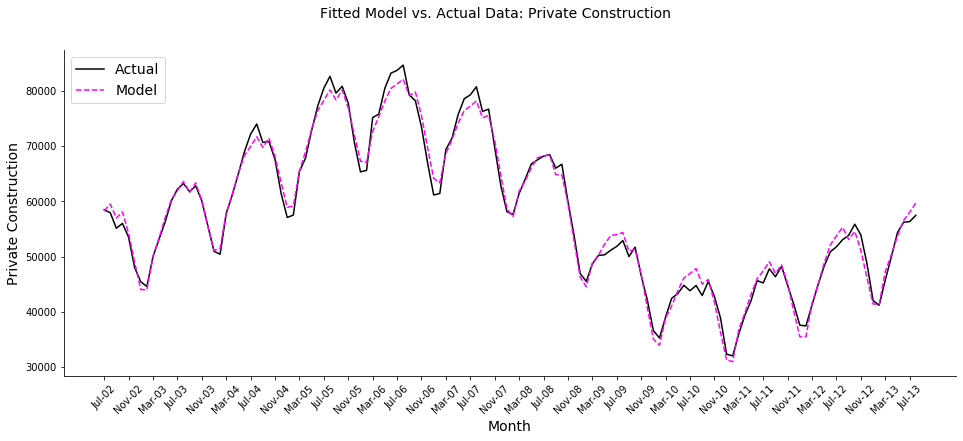

```python
x = priv_df['Date']

fig, ax = plt.subplots()
fig.suptitle('Fitted Model vs. Actual Data: Private Construction', fontsize = 14)
fig.set_size_inches(16,6)
ax.plot(x, priv_df['Private'],c='black', label = 'Actual')
ax.plot(x, priv_df['Composite'],c='fuchsia', label = 'Model', linestyle = 'dashed')   # 'Composite' serves as our model

ax.set_xticks(x[::4])
ax.set_xticklabels(x[::4])
ax.spines['top'].set_visible(False)
ax.spines['right'].set_visible(False)
ax.set_xlabel('Month', fontsize = 14)
plt.xticks(rotation=45)
ax.set_ylabel('Private Construction', fontsize = 14)
ax.legend(loc = 2, fontsize = 14)
plt.show()
```

### Histogram of Final Residuals

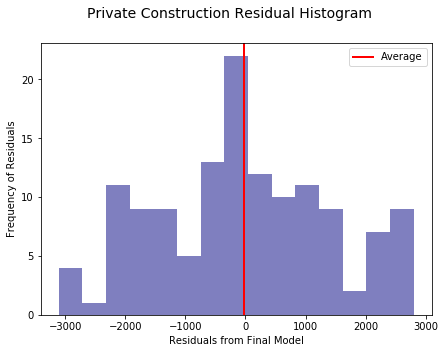

```python
avg_resid = priv_df['R2'].mean()

fig, ax = plt.subplots()
ax.hist(x = priv_df['R2'], bins = 15, facecolor='navy', alpha=0.5)
# 'hist' signals a histogram

fig.suptitle('Private Construction Residual Histogram', fontsize = 14)
fig.set_size_inches(7,5)
ax.axvline(x=avg_resid,linewidth=2,color='red',linestyle='-', label = 'Average')

ax.xaxis.set_label_text('Residuals from Final Model')
ax.xaxis.set_tick_params(which = 'both', top = False, bottom = True, labelbottom = True)  # Turn top x axis tick marks off
ax.yaxis.set_label_text('Frequency of Residuals')
ax.yaxis.set_tick_params(which = 'both', right = False, left = True, labelleft = True)   # Turn right y axis tick marks off
ax.legend()
plt.show()
```